# DS 621 Fall2020: Homework 5 (Group3)

Wine Regression

Zach Alexander, Sam Bellows, Donny Lofland, Joshua Registe, Neil Shah, Aaron Zalki

## Overview

The wine dataset is a highly popular one in the data science community, as it models some of the challenges of real world datasets and can be modeled by a variety of different model types.

## 1. Data Exploration

### Dataset

The wine training set contains 16 columns - including the target variable `TARGET` - and 12795 rows, covering a variety of different brands of wine. The data-set is entirely numerical variables, but also contains some variables that are highly discrete and have a limited number of possible values. We believe it is still reasonable to treat these as numerical variables since the different values follow a natural numerical order.

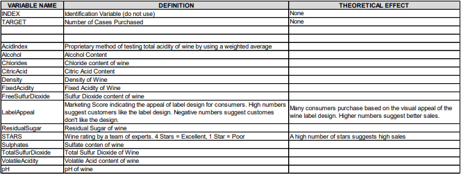

Variables of Interest

Given that the Index column had no impact on the target variable, number of wines, it was dropped.

### Summary Stats

We compiled summary statistics on our data set to better understand the data before modeling.

Data summary

| Name | df |
| --- | --- |
| Number of rows | 12795 |
| Number of columns | 15 |
| _______________________ |  |
| Column type frequency: |  |
| numeric | 15 |
| ________________________ |  |
| Group variables | None |

**Variable type: numeric**

| skim_variable | n_missing | complete_rate | mean | sd | p0 | p25 | p50 | p75 | p100 | hist |
| --- | --- | --- | --- | --- | --- | --- | --- | --- | --- | --- |
| TARGET | 0 | 1.00 | 3.03 | 1.93 | 0.00 | 2.00 | 3.00 | 4.00 | 8.00 | ▆▇▇▆▁ |
| FixedAcidity | 0 | 1.00 | 7.08 | 6.32 | -18.10 | 5.20 | 6.90 | 9.50 | 34.40 | ▁▂▇▂▁ |
| VolatileAcidity | 0 | 1.00 | 0.32 | 0.78 | -2.79 | 0.13 | 0.28 | 0.64 | 3.68 | ▁▂▇▂▁ |
| CitricAcid | 0 | 1.00 | 0.31 | 0.86 | -3.24 | 0.03 | 0.31 | 0.58 | 3.86 | ▁▂▇▂▁ |
| ResidualSugar | 616 | 0.95 | 5.42 | 33.75 | -127.80 | -2.00 | 3.90 | 15.90 | 141.15 | ▁▂▇▂▁ |
| Chlorides | 638 | 0.95 | 0.05 | 0.32 | -1.17 | -0.03 | 0.05 | 0.15 | 1.35 | ▁▂▇▂▁ |
| FreeSulfurDioxide | 647 | 0.95 | 30.85 | 148.71 | -555.00 | 0.00 | 30.00 | 70.00 | 623.00 | ▁▂▇▂▁ |
| TotalSulfurDioxide | 682 | 0.95 | 120.71 | 231.91 | -823.00 | 27.00 | 123.00 | 208.00 | 1057.00 | ▁▂▇▂▁ |
| Density | 0 | 1.00 | 0.99 | 0.03 | 0.89 | 0.99 | 0.99 | 1.00 | 1.10 | ▁▂▇▂▁ |
| pH | 395 | 0.97 | 3.21 | 0.68 | 0.48 | 2.96 | 3.20 | 3.47 | 6.13 | ▁▂▇▂▁ |
| Sulphates | 1210 | 0.91 | 0.53 | 0.93 | -3.13 | 0.28 | 0.50 | 0.86 | 4.24 | ▁▂▇▂▁ |
| Alcohol | 653 | 0.95 | 10.49 | 3.73 | -4.70 | 9.00 | 10.40 | 12.40 | 26.50 | ▁▂▇▂▁ |
| LabelAppeal | 0 | 1.00 | -0.01 | 0.89 | -2.00 | -1.00 | 0.00 | 1.00 | 2.00 | ▁▅▇▅▁ |
| AcidIndex | 0 | 1.00 | 7.77 | 1.32 | 4.00 | 7.00 | 8.00 | 8.00 | 17.00 | ▁▇▁▁▁ |
| STARS | 3359 | 0.74 | 2.04 | 0.90 | 1.00 | 1.00 | 2.00 | 3.00 | 4.00 | ▇▇▁▅▂ |

The first observation is the prevalance of NA’s throughout the dataset. Of the 14 feature columns, 8 of them contain at least some NA values. We also see that the `TARGET` value is always between 0 and 8, which makes sense as this is the “Number of Cases of Wine Sold” (we would not expect partial cases).

### Distributions

Next, we wanted to get an idea of the distribution profiles for each of the variables.

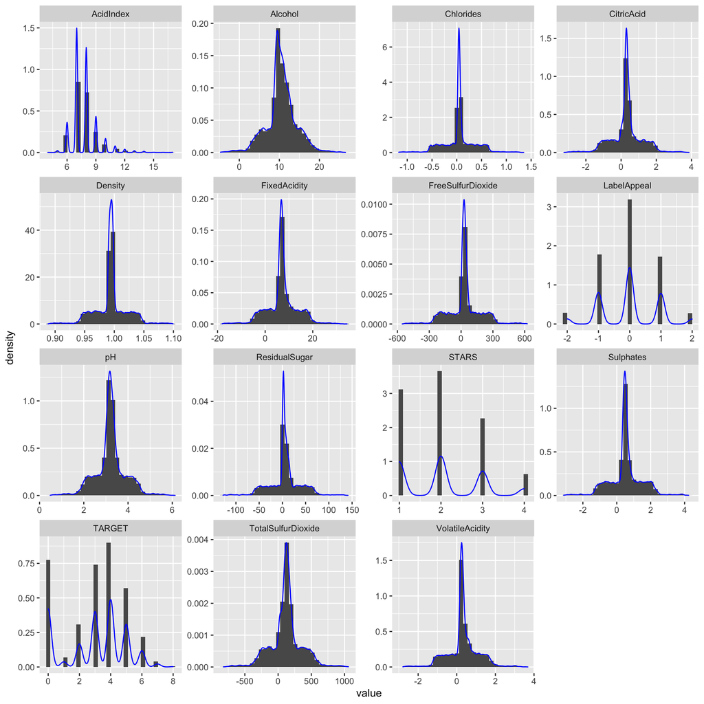

We see that most variables have a somewhat normal (although steep) distribution.

The distribution profiles show right skew in variables `AcidIndex`, and `STARS`.

More interesting is the shape of many features where they are centered with most values clustered at the center and somewhat uniform shape above and below. It almost appears like a tri-modal distribution with a low, middle and high normal distributions overlapping. We are not going to do extensive feature engineer, or we might consider breaking these features up into 3 separate features each. Two approaches include:

1. Use `mixTools` to separate the multi-modal curves into 3 distinct (and separate) features each capturing just the `low`, `middle` or `high` values and retaining a numerical value.
2. Discretize the features converting them into categorical values indicating `low`, `middle` or `high` value.

### Boxplots

In addition to creating histogram distributions, we also elected to use box-plots to get an idea of the spread of each variable.

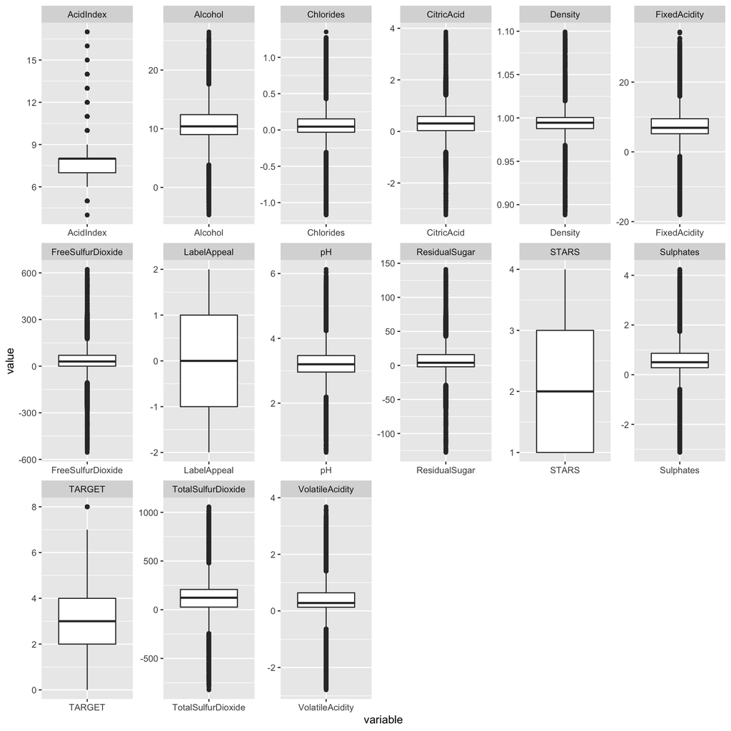

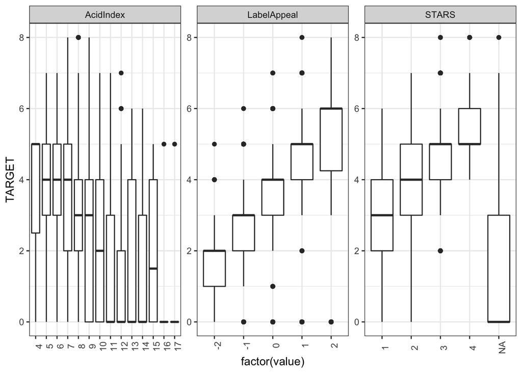

The box-plots do not reveal any enormous outliers in any of the features, meaning it is unlikely we will need to perform outlier detection and removal. `AcidIndex`, `LabelAppeal`, and `STARS` are essentially categorical in nature (ordinal), so we explore how each value of those features relates with `TARGET`. We see a clear relationship - as `LabelAppeal` increases, so does `TARGET`.

We see the same relationship between `STARS` and `TARGET` - we especially note that `STARS=NA` highly correlates with lower `TARGET`. In the original project instructions, attention was drawn to the fact that missing data might be informative. Based on this, we will impute `STARS=NA` into `STARS=0` which fits with the other values we see for `STARS` and the pattern that as stars increase, cases sold increase.

### Variable Plots

Finally, we wanted to plot scatter plots of each variable versus the target variable, TARGET, to get an idea of the relationship between them.

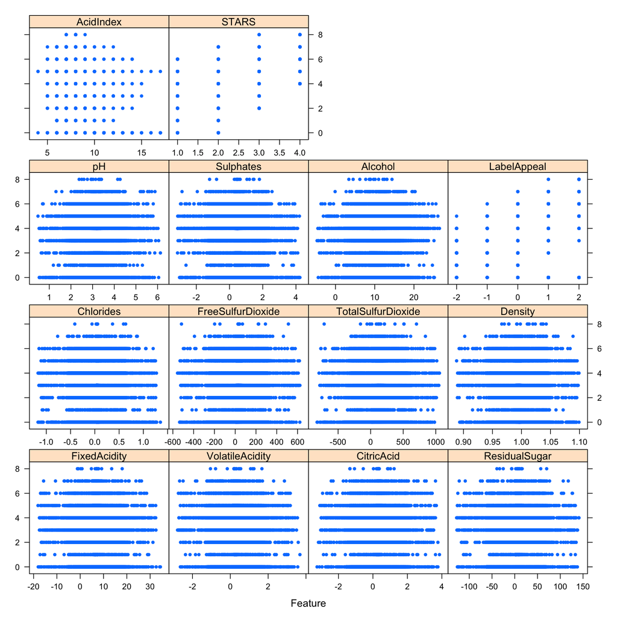

Due to the discrete nature of the target, it is somewhat difficult to see clear linear relationships in the data. However, it does appear that both `STARS` and `LabelAppeal` have a significant positive relationship with the `TARGET`, and many of the chemical features have at least some negative relationship with the `TARGET` as lower values led to more values of 8 and 7 in the target variable.

Overall, although our plots indicate some interesting relationships between our variables, they also reveal some significant issues with the data.

For instance, most of the predictor variables are skewed or non-normally distributed, and will need to be transformed. Additionally, there are many data points that contain missing data that will need to be either imputed or discarded. There also was the issue of nonsensical negative values. We have chosen to take the absolute value of these as the feature value as there are so many of these values: however, there is no evidence to back up that this is a correct decision and that these values are not simply missing.

### Missing Data

When we initially viewed the first few rows of the raw data, we already noticed missing data. Let’s assess which fields have missing data.

```
##    values                ind
## 1   26.25              STARS
## 2    9.46          Sulphates
## 3    5.33 TotalSulfurDioxide
## 4    5.10            Alcohol
## 5    5.06  FreeSulfurDioxide
## 6    4.99          Chlorides
## 7    4.81      ResidualSugar
## 8    3.09                 pH
## 9    0.00             TARGET
## 10   0.00       FixedAcidity
## 11   0.00    VolatileAcidity
## 12   0.00         CitricAcid
## 13   0.00            Density
## 14   0.00        LabelAppeal
## 15   0.00          AcidIndex
```

### Feature-Target Correlations

```
##          values                ind
## 1   0.685381473              STARS
## 2   0.356500469        LabelAppeal
## 3   0.062030498            Alcohol
## 4   0.051730323 TotalSulfurDioxide
## 5   0.043996542  FreeSulfurDioxide
## 6   0.016187709      ResidualSugar
## 7   0.008684633         CitricAcid
## 8  -0.009081197                 pH
## 9  -0.035589560            Density
## 10 -0.039072231          Chlorides
## 11 -0.039917146          Sulphates
## 12 -0.049010939       FixedAcidity
## 13 -0.088793212    VolatileAcidity
## 14 -0.221991949          AcidIndex
```

### Multicolinearity

One problem that can occur with multi-variable regression is correlation between variables, or multicolinearity. A quick check is to run correlations between variables.

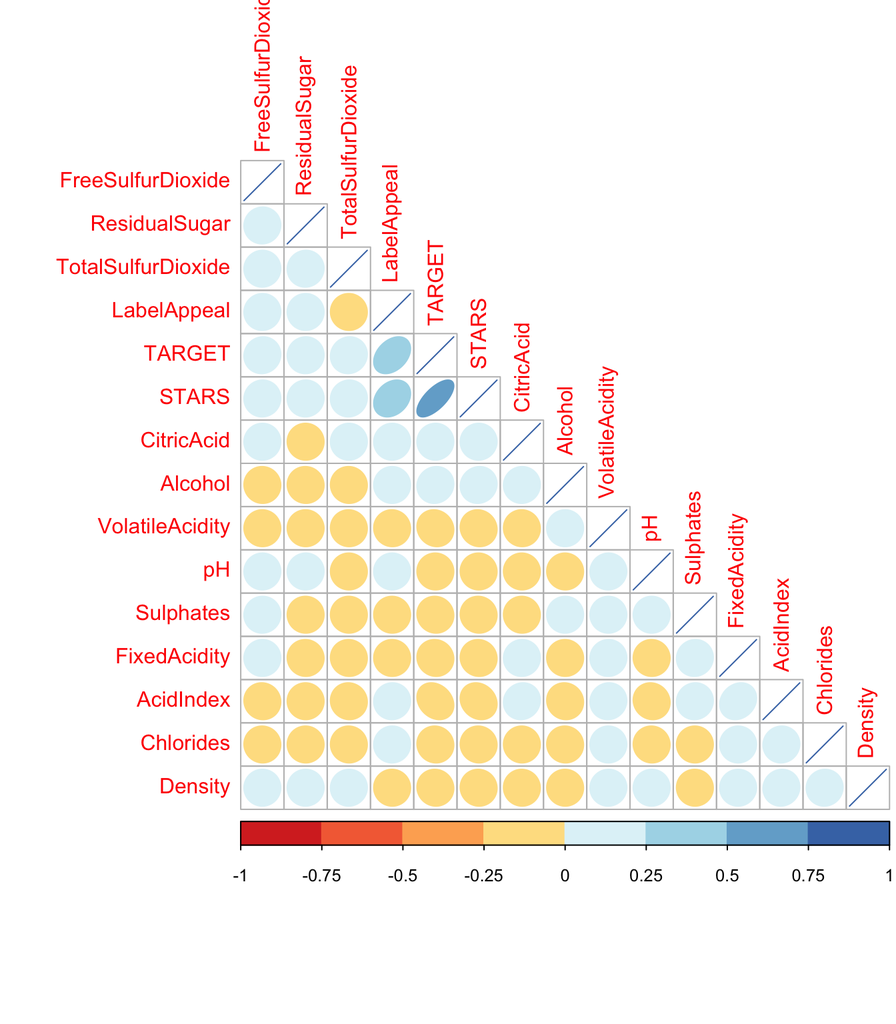

We see that the features have very low correlations with each other, meaning that there is not much multicollinearity present in the dataset. This means that the assumptions of linear regression are more likely to be met.

## 2. Data Preparation

To summarize our data preparation and exploration, we can distinguish our findings into a few categories below:

### Removed Fields

We removed the INDEX field as it offers no information for a model.

### Outliers

Many of the numerical features had unreasonable negative values. We transformed these to be the absolute value of the feature, as a data entry error seems likely given the quantity of negative records.

### Transform non-normal variables

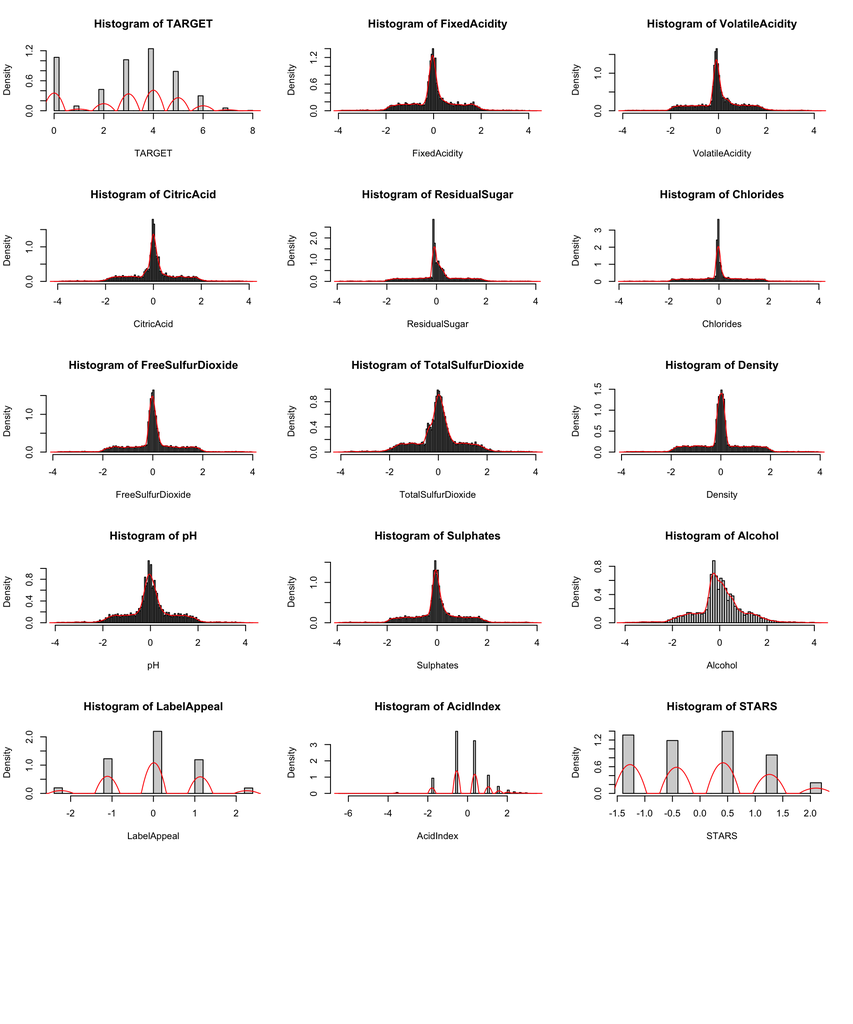

We see that after the transformations, the variables are more centered and more closely resemble a normal distribution, although clearly they are still not perfect normal distributions.

### Finalizing the dataset for model building

```
## [1] "Number of Training Samples:  10238"
```

```
## [1] "Number of Testing Samples:  2557"
```

## 3. Model Building

### Poisson Model 1

In this first model, we include all available features. Features include:

`FixedAcidity`, `VolatileAcidity`, `CitricAcid`, `ResidualSugar`, `Chlorides`, `FreeSulfurDioxide`, `TotalSulfurDioxide`, `Density`, `pH`, `Sulphates`, `Alcohol`, `LabelAppeal`, `AcidIndex`, `STARS`

```
##
## Call:
## glm(formula = TARGET ~ FixedAcidity + VolatileAcidity + CitricAcid +
##     ResidualSugar + Chlorides + FreeSulfurDioxide + TotalSulfurDioxide +
##     Density + pH + Sulphates + Alcohol + as.factor(LabelAppeal) +
##     as.factor(AcidIndex) + as.factor(STARS), family = poisson,
##     data = trainingData)
##
## Deviance Residuals:
##     Min       1Q   Median       3Q      Max
## -3.2271  -0.6519  -0.0034   0.4546   3.6804
##
## Coefficients:
##                                             Estimate  Std. Error z value
## (Intercept)                                0.0370299   0.3197761   0.116
## FixedAcidity                               0.0002075   0.0058156   0.036
## VolatileAcidity                           -0.0225679   0.0057403  -3.931
## CitricAcid                                 0.0027544   0.0057223   0.481
## ResidualSugar                              0.0030557   0.0058435   0.523
## Chlorides                                 -0.0105087   0.0058800  -1.787
## FreeSulfurDioxide                          0.0138176   0.0057331   2.410
## TotalSulfurDioxide                         0.0218179   0.0058745   3.714
## Density                                   -0.0059405   0.0057148  -1.039
## pH                                        -0.0034042   0.0058317  -0.584
## Sulphates                                 -0.0135930   0.0059053  -2.302
## Alcohol                                    0.0151789   0.0058613   2.590
## as.factor(LabelAppeal)-1.11204793733397    0.2325701   0.0427873   5.435
## as.factor(LabelAppeal)0.0101741115806247   0.4230512   0.0417301  10.138
## as.factor(LabelAppeal)1.13239616049522     0.5473965   0.0424691  12.889
## as.factor(LabelAppeal)2.25461820940981     0.6928260   0.0475218  14.579
## as.factor(AcidIndex)-3.59682937695875     -0.1542349   0.3244721  -0.475
## as.factor(AcidIndex)-1.79176983045029     -0.1138674   0.3174850  -0.359
## as.factor(AcidIndex)-0.545318540973785    -0.1500294   0.3171584  -0.473
## as.factor(AcidIndex)0.362910765511677     -0.1882319   0.3172130  -0.593
## as.factor(AcidIndex)1.05172974217783      -0.2975012   0.3176496  -0.937
## as.factor(AcidIndex)1.59059728918163      -0.4282568   0.3189792  -1.343
## as.factor(AcidIndex)2.02271372429848      -0.8102166   0.3238373  -2.502
## as.factor(AcidIndex)2.37629509167962      -0.8032321   0.3299756  -2.434
## as.factor(AcidIndex)2.67051656830802      -0.6561190   0.3330054  -1.970
## as.factor(AcidIndex)2.9188445277671       -0.9728241   0.3573778  -2.722
```

[output cut: 36 more lines]

```
## as.factor(AcidIndex)3.47378568897179                 0.078593 .
## as.factor(STARS)-0.42623524866846        < 0.0000000000000002 ***
## as.factor(STARS)0.416552574962037        < 0.0000000000000002 ***
## as.factor(STARS)1.25934039859254         < 0.0000000000000002 ***
## as.factor(STARS)2.10212822222303         < 0.0000000000000002 ***
## ---
## Signif. codes:  0 '***' 0.001 '**' 0.01 '*' 0.05 '.' 0.1 ' ' 1
##
## (Dispersion parameter for poisson family taken to be 1)
##
##     Null deviance: 18306  on 10237  degrees of freedom
## Residual deviance: 10875  on 10205  degrees of freedom
## AIC: 36503
##
## Number of Fisher Scoring iterations: 9
```

```
##          RMSE      Rsquared           MAE           aic           bic
##     2.5961636     0.4836248     2.2304795 36502.5519337 36741.2693654
```

### Poisson Model 2

In this second model, we only include the most predictive features based on our first Poisson Model. The predictors for the following model are:

`VolatileAcidity`, `TotalSulfurDioxide`, `Alcohol`, `LabelAppeal`, `AcidIndex`, `STARS`

```
##
## Call:
## glm(formula = TARGET ~ VolatileAcidity + TotalSulfurDioxide +
##     Alcohol + as.factor(LabelAppeal) + as.factor(AcidIndex) +
##     as.factor(STARS), family = poisson, data = clean_df)
##
## Deviance Residuals:
##     Min       1Q   Median       3Q      Max
## -3.2335  -0.6501  -0.0035   0.4410   3.6951
##
## Coefficients:
##                                           Estimate Std. Error z value
## (Intercept)                               0.001201   0.318675   0.004
## VolatileAcidity                          -0.023533   0.005122  -4.595
## TotalSulfurDioxide                        0.016952   0.005244   3.232
## Alcohol                                   0.016009   0.005231   3.060
## as.factor(LabelAppeal)-1.11204793733397   0.240289   0.037999   6.324
## as.factor(LabelAppeal)0.0101741115806247  0.430806   0.037064  11.623
## as.factor(LabelAppeal)1.13239616049522    0.564104   0.037710  14.959
## as.factor(LabelAppeal)2.25461820940981    0.699216   0.042446  16.473
## as.factor(AcidIndex)-3.59682937695875    -0.140143   0.322337  -0.435
## as.factor(AcidIndex)-1.79176983045029    -0.097789   0.316887  -0.309
## as.factor(AcidIndex)-0.545318540973785   -0.131342   0.316605  -0.415
## as.factor(AcidIndex)0.362910765511677    -0.162635   0.316637  -0.514
## as.factor(AcidIndex)1.05172974217783     -0.272917   0.316940  -0.861
## as.factor(AcidIndex)1.59059728918163     -0.432064   0.318025  -1.359
## as.factor(AcidIndex)2.02271372429848     -0.795786   0.321596  -2.474
## as.factor(AcidIndex)2.37629509167962     -0.810861   0.327262  -2.478
## as.factor(AcidIndex)2.67051656830802     -0.646459   0.330156  -1.958
## as.factor(AcidIndex)2.9188445277671      -0.738613   0.342710  -2.155
## as.factor(AcidIndex)3.13100139587667     -0.286638   0.403433  -0.710
## as.factor(AcidIndex)3.31417429494859     -0.951704   0.547993  -1.737
## as.factor(AcidIndex)3.47378568897179     -1.196936   0.548071  -2.184
## as.factor(STARS)-0.42623524866846         0.757245   0.019564  38.705
## as.factor(STARS)0.416552574962037         1.075518   0.018261  58.896
## as.factor(STARS)1.25934039859254          1.194174   0.019232  62.093
## as.factor(STARS)2.10212822222303          1.313789   0.024330  53.999
##                                                      Pr(>|z|)
## (Intercept)                                           0.99699
## VolatileAcidity                                0.000004335408 ***
```

[output cut: 18 more lines]

```
## as.factor(AcidIndex)3.47378568897179                  0.02897 *
## as.factor(STARS)-0.42623524866846        < 0.0000000000000002 ***
## as.factor(STARS)0.416552574962037        < 0.0000000000000002 ***
## as.factor(STARS)1.25934039859254         < 0.0000000000000002 ***
## as.factor(STARS)2.10212822222303         < 0.0000000000000002 ***
## ---
## Signif. codes:  0 '***' 0.001 '**' 0.01 '*' 0.05 '.' 0.1 ' ' 1
##
## (Dispersion parameter for poisson family taken to be 1)
##
##     Null deviance: 22861  on 12794  degrees of freedom
## Residual deviance: 13550  on 12770  degrees of freedom
## AIC: 45542
##
## Number of Fisher Scoring iterations: 6
```

```
##          RMSE      Rsquared           MAE           aic           bic
##     2.5906527     0.5164851     2.2282671 45542.3183589 45728.7386026
```

### Negative Binomial Model 3

Similar to Poisson Model 1, the predictors for the following model are:

`FixedAcidity`, `VolatileAcidity`, `CitricAcid`, `ResidualSugar`, `Chlorides`, `FreeSulfurDioxide`, `TotalSulfurDioxide`, `Density`, `pH`, `Sulphates`, `Alcohol`, `LabelAppeal`, `AcidIndex`, `STARS`

```
##
## Call:
## glm.nb(formula = TARGET ~ FixedAcidity + VolatileAcidity + CitricAcid +
##     ResidualSugar + Chlorides + FreeSulfurDioxide + TotalSulfurDioxide +
##     Density + pH + Sulphates + Alcohol + as.factor(LabelAppeal) +
##     as.factor(AcidIndex) + as.factor(STARS), data = clean_df,
##     init.theta = 40957.00204, link = log)
##
## Deviance Residuals:
##     Min       1Q   Median       3Q      Max
## -3.2219  -0.6496  -0.0055   0.4446   3.6790
##
## Coefficients:
##                                            Estimate Std. Error z value
## (Intercept)                               0.0275198  0.3190721   0.086
## FixedAcidity                              0.0010176  0.0051829   0.196
## VolatileAcidity                          -0.0231944  0.0051231  -4.527
## CitricAcid                                0.0039724  0.0050838   0.781
## ResidualSugar                             0.0005767  0.0052060   0.111
## Chlorides                                -0.0122552  0.0052206  -2.347
## FreeSulfurDioxide                         0.0132531  0.0051832   2.557
## TotalSulfurDioxide                        0.0170166  0.0052484   3.242
## Density                                  -0.0074549  0.0050938  -1.464
## pH                                       -0.0066655  0.0051875  -1.285
## Sulphates                                -0.0106282  0.0053149  -2.000
## Alcohol                                   0.0157805  0.0052355   3.014
## as.factor(LabelAppeal)-1.11204793733397   0.2398534  0.0380017   6.312
## as.factor(LabelAppeal)0.0101741115806247  0.4300463  0.0370666  11.602
## as.factor(LabelAppeal)1.13239616049522    0.5633460  0.0377142  14.937
## as.factor(LabelAppeal)2.25461820940981    0.6992610  0.0424548  16.471
## as.factor(AcidIndex)-3.59682937695875    -0.1651538  0.3226593  -0.512
## as.factor(AcidIndex)-1.79176983045029    -0.1214774  0.3172467  -0.383
## as.factor(AcidIndex)-0.545318540973785   -0.1558113  0.3169954  -0.492
## as.factor(AcidIndex)0.362910765511677    -0.1871144  0.3170413  -0.590
## as.factor(AcidIndex)1.05172974217783     -0.2972766  0.3173791  -0.937
## as.factor(AcidIndex)1.59059728918163     -0.4542592  0.3184811  -1.426
## as.factor(AcidIndex)2.02271372429848     -0.8158352  0.3220684  -2.533
## as.factor(AcidIndex)2.37629509167962     -0.8303961  0.3277299  -2.534
## as.factor(AcidIndex)2.67051656830802     -0.6688133  0.3306330  -2.023
## as.factor(AcidIndex)2.9188445277671      -0.7687131  0.3432641  -2.239
```

[output cut: 43 more lines]

```
##
## (Dispersion parameter for Negative Binomial(40957) family taken to be 1)
##
##     Null deviance: 22860  on 12794  degrees of freedom
## Residual deviance: 13529  on 12762  degrees of freedom
## AIC: 45540
##
## Number of Fisher Scoring iterations: 1
##
##
##               Theta:  40957
##           Std. Err.:  34344
## Warning while fitting theta: iteration limit reached
##
##  2 x log-likelihood:  -45472.13
```

```
##          RMSE      Rsquared           MAE           aic           bic
##     2.5903198     0.5175937     2.2277657 45540.1321552 45793.6636866
```

### Negative Binomial Model 4

Similar to Poisson Model 2, the predictors for the following model are:

`VolatileAcidity`, `FreeSulfurDioxide`, `TotalSulfurDioxide`, `Alcohol`, `LabelAppeal`, `AcidIndex`, `STARS`

```
##
## Call:
## glm.nb(formula = TARGET ~ VolatileAcidity + FreeSulfurDioxide +
##     TotalSulfurDioxide + Alcohol + as.factor(LabelAppeal) + as.factor(AcidIndex) +
##     as.factor(STARS), data = clean_df, init.theta = 40912.67371,
##     link = log)
##
## Deviance Residuals:
##     Min       1Q   Median       3Q      Max
## -3.2456  -0.6517  -0.0038   0.4399   3.6952
##
## Coefficients:
##                                           Estimate Std. Error z value
## (Intercept)                               0.014317   0.318731   0.045
## VolatileAcidity                          -0.023451   0.005122  -4.578
## FreeSulfurDioxide                         0.013266   0.005179   2.562
## TotalSulfurDioxide                        0.016879   0.005244   3.219
## Alcohol                                   0.016237   0.005231   3.104
## as.factor(LabelAppeal)-1.11204793733397   0.240039   0.038000   6.317
## as.factor(LabelAppeal)0.0101741115806247  0.430314   0.037065  11.610
## as.factor(LabelAppeal)1.13239616049522    0.563287   0.037712  14.936
## as.factor(LabelAppeal)2.25461820940981    0.698162   0.042449  16.447
## as.factor(AcidIndex)-3.59682937695875    -0.154135   0.322401  -0.478
## as.factor(AcidIndex)-1.79176983045029    -0.110580   0.316945  -0.349
## as.factor(AcidIndex)-0.545318540973785   -0.143771   0.316660  -0.454
## as.factor(AcidIndex)0.362910765511677    -0.174856   0.316690  -0.552
## as.factor(AcidIndex)1.05172974217783     -0.285228   0.316994  -0.900
## as.factor(AcidIndex)1.59059728918163     -0.443142   0.318072  -1.393
## as.factor(AcidIndex)2.02271372429848     -0.806122   0.321638  -2.506
## as.factor(AcidIndex)2.37629509167962     -0.819576   0.327296  -2.504
## as.factor(AcidIndex)2.67051656830802     -0.655682   0.330193  -1.986
## as.factor(AcidIndex)2.9188445277671      -0.753474   0.342775  -2.198
## as.factor(AcidIndex)3.13100139587667     -0.299583   0.403483  -0.742
## as.factor(AcidIndex)3.31417429494859     -0.953685   0.548008  -1.740
## as.factor(AcidIndex)3.47378568897179     -1.205542   0.548094  -2.200
## as.factor(STARS)-0.42623524866846         0.756497   0.019567  38.662
## as.factor(STARS)0.416552574962037         1.074730   0.018264  58.844
## as.factor(STARS)1.25934039859254          1.193602   0.019234  62.057
## as.factor(STARS)2.10212822222303          1.314420   0.024331  54.023
##                                                      Pr(>|z|)
```

[output cut: 28 more lines]

```
##
## (Dispersion parameter for Negative Binomial(40912.67) family taken to be 1)
##
##     Null deviance: 22860  on 12794  degrees of freedom
## Residual deviance: 13543  on 12769  degrees of freedom
## AIC: 45540
##
## Number of Fisher Scoring iterations: 1
##
##
##               Theta:  40913
##           Std. Err.:  34297
## Warning while fitting theta: iteration limit reached
##
##  2 x log-likelihood:  -45486.18
```

```
##          RMSE      Rsquared           MAE           aic           bic
##     2.5904952     0.5169113     2.2280978 45540.1774667 45741.5113299
```

### Linear Model 5

The predictors for the following model are:

`FixedAcidity`, `VolatileAcidity`, `CitricAcid`, `ResidualSugar`, `Chlorides`, `FreeSulfurDioxide`, `TotalSulfurDioxide`, `Density`, `pH`, `Sulphates`, `Alcohol`, `LabelAppeal`, `AcidIndex`, `STARS`

```
##
## Call:
## lm(formula = TARGET ~ FixedAcidity + VolatileAcidity + CitricAcid +
##     ResidualSugar + Chlorides + FreeSulfurDioxide + TotalSulfurDioxide +
##     Density + pH + Sulphates + Alcohol + as.factor(LabelAppeal) +
##     as.factor(AcidIndex) + as.factor(STARS), data = clean_df)
##
## Residuals:
##     Min      1Q  Median      3Q     Max
## -4.9635 -0.8591  0.0325  0.8384  6.0750
##
## Coefficients:
##                                           Estimate Std. Error t value
## (Intercept)                               0.995095   0.755491   1.317
## FixedAcidity                              0.004930   0.011720   0.421
## VolatileAcidity                          -0.073667   0.011565  -6.370
## CitricAcid                                0.014455   0.011558   1.251
## ResidualSugar                             0.004027   0.011782   0.342
## Chlorides                                -0.038485   0.011776  -3.268
## FreeSulfurDioxide                         0.039825   0.011786   3.379
## TotalSulfurDioxide                        0.049447   0.011816   4.185
## Density                                  -0.022475   0.011545  -1.947
## pH                                       -0.018619   0.011704  -1.591
## Sulphates                                -0.028248   0.012015  -2.351
## Alcohol                                   0.050812   0.011830   4.295
## as.factor(LabelAppeal)-1.11204793733397   0.367639   0.062729   5.861
## as.factor(LabelAppeal)0.0101741115806247  0.835185   0.061168  13.654
## as.factor(LabelAppeal)1.13239616049522    1.302062   0.063917  20.371
## as.factor(LabelAppeal)2.25461820940981    1.889951   0.084169  22.454
## as.factor(AcidIndex)-3.59682937695875    -0.334854   0.767938  -0.436
## as.factor(AcidIndex)-1.79176983045029    -0.220221   0.754101  -0.292
## as.factor(AcidIndex)-0.545318540973785   -0.322349   0.753472  -0.428
## as.factor(AcidIndex)0.362910765511677    -0.429363   0.753539  -0.570
## as.factor(AcidIndex)1.05172974217783     -0.732560   0.754117  -0.971
## as.factor(AcidIndex)1.59059728918163     -1.041297   0.755385  -1.378
## as.factor(AcidIndex)2.02271372429848     -1.513113   0.757752  -1.997
## as.factor(AcidIndex)2.37629509167962     -1.533481   0.762156  -2.012
## as.factor(AcidIndex)2.67051656830802     -1.552014   0.769606  -2.017
## as.factor(AcidIndex)2.9188445277671      -1.400154   0.777299  -1.801
## as.factor(AcidIndex)3.13100139587667     -0.692206   0.883131  -0.784
```

[output cut: 31 more lines]

```
## as.factor(AcidIndex)2.67051656830802                  0.04375 *
## as.factor(AcidIndex)2.9188445277671                   0.07168 .
## as.factor(AcidIndex)3.13100139587667                  0.43317
## as.factor(AcidIndex)3.31417429494859                  0.06293 .
## as.factor(AcidIndex)3.47378568897179                  0.03304 *
## as.factor(STARS)-0.42623524866846        < 0.0000000000000002 ***
## as.factor(STARS)0.416552574962037        < 0.0000000000000002 ***
## as.factor(STARS)1.25934039859254         < 0.0000000000000002 ***
## as.factor(STARS)2.10212822222303         < 0.0000000000000002 ***
## ---
## Signif. codes:  0 '***' 0.001 '**' 0.01 '*' 0.05 '.' 0.1 ' ' 1
##
## Residual standard error: 1.302 on 12762 degrees of freedom
## Multiple R-squared:  0.5441, Adjusted R-squared:  0.5429
## F-statistic: 475.9 on 32 and 12762 DF,  p-value: < 0.00000000000000022
```

```
##          RMSE      Rsquared           MAE           aic           bic
##     1.3053743     0.5415453     1.0235055 43106.3022739 43359.8338054
```

### Linear Model 6

For the final Linear Model, we leverage `stepAIC` on our Linear Model #5 to choose the most important features.

```
##
## Call:
## lm(formula = TARGET ~ VolatileAcidity + Chlorides + FreeSulfurDioxide +
##     TotalSulfurDioxide + Density + pH + Sulphates + Alcohol +
##     as.factor(LabelAppeal) + as.factor(AcidIndex) + as.factor(STARS),
##     data = clean_df)
##
## Residuals:
##     Min      1Q  Median      3Q     Max
## -4.9616 -0.8590  0.0352  0.8399  6.0675
##
## Coefficients:
##                                          Estimate Std. Error t value
## (Intercept)                               0.99019    0.75488   1.312
## VolatileAcidity                          -0.07393    0.01156  -6.394
## Chlorides                                -0.03864    0.01177  -3.282
## FreeSulfurDioxide                         0.04009    0.01178   3.403
## TotalSulfurDioxide                        0.04960    0.01181   4.200
## Density                                  -0.02270    0.01154  -1.967
## pH                                       -0.01862    0.01170  -1.591
## Sulphates                                -0.02837    0.01201  -2.362
## Alcohol                                   0.05100    0.01183   4.313
## as.factor(LabelAppeal)-1.11204793733397   0.36722    0.06272   5.854
## as.factor(LabelAppeal)0.0101741115806247  0.83483    0.06116  13.649
## as.factor(LabelAppeal)1.13239616049522    1.30161    0.06391  20.367
## as.factor(LabelAppeal)2.25461820940981    1.88998    0.08416  22.456
## as.factor(AcidIndex)-3.59682937695875    -0.33511    0.76744  -0.437
## as.factor(AcidIndex)-1.79176983045029    -0.21824    0.75353  -0.290
## as.factor(AcidIndex)-0.545318540973785   -0.31837    0.75287  -0.423
## as.factor(AcidIndex)0.362910765511677    -0.42442    0.75293  -0.564
## as.factor(AcidIndex)1.05172974217783     -0.72561    0.75343  -0.963
## as.factor(AcidIndex)1.59059728918163     -1.03390    0.75463  -1.370
## as.factor(AcidIndex)2.02271372429848     -1.50407    0.75695  -1.987
## as.factor(AcidIndex)2.37629509167962     -1.52217    0.76131  -1.999
## as.factor(AcidIndex)2.67051656830802     -1.54018    0.76867  -2.004
## as.factor(AcidIndex)2.9188445277671      -1.38512    0.77635  -1.784
## as.factor(AcidIndex)3.13100139587667     -0.67937    0.88243  -0.770
## as.factor(AcidIndex)3.31417429494859     -1.75343    0.95178  -1.842
## as.factor(AcidIndex)3.47378568897179     -1.89498    0.89978  -2.106
## as.factor(STARS)-0.42623524866846         1.34682    0.03291  40.918
```

[output cut: 25 more lines]

```
## as.factor(AcidIndex)2.67051656830802                 0.045124 *
## as.factor(AcidIndex)2.9188445277671                  0.074426 .
## as.factor(AcidIndex)3.13100139587667                 0.441383
## as.factor(AcidIndex)3.31417429494859                 0.065461 .
## as.factor(AcidIndex)3.47378568897179                 0.035220 *
## as.factor(STARS)-0.42623524866846        < 0.0000000000000002 ***
## as.factor(STARS)0.416552574962037        < 0.0000000000000002 ***
## as.factor(STARS)1.25934039859254         < 0.0000000000000002 ***
## as.factor(STARS)2.10212822222303         < 0.0000000000000002 ***
## ---
## Signif. codes:  0 '***' 0.001 '**' 0.01 '*' 0.05 '.' 0.1 ' ' 1
##
## Residual standard error: 1.302 on 12765 degrees of freedom
## Multiple R-squared:  0.544,  Adjusted R-squared:  0.543
## F-statistic: 525.1 on 29 and 12765 DF,  p-value: < 0.00000000000000022
```

```
##          RMSE      Rsquared           MAE           aic           bic
##     1.3054450     0.5414958     1.0235800 43102.1597330 43333.3208352
```

## 4. Model Selection & Analysis

This table summarizes the **RMSE**, **$R^2$**, **MAE**, **AIC** and **BIC** for all 6 models. In terms of raw metrics, The Linear regressions (**lm5** and **lm6**) had the overall best performance based on **RMSE** and **$R62$**; however, **Poisson Model 1** had the best performance based on **AIC** and **BIC**.

|  | RMSE | Rsquared | MAE | aic | bic |
| --- | --- | --- | --- | --- | --- |
| poiss1_eval | 2.596164 | 0.4836248 | 2.230479 | 36502.55 | 36741.27 |
| poiss2_eval | 2.590653 | 0.5164851 | 2.228267 | 45542.32 | 45728.74 |
| nb3_eval | 2.590320 | 0.5175937 | 2.227766 | 45540.13 | 45793.66 |
| nb4_eval | 2.590495 | 0.5169113 | 2.228098 | 45540.18 | 45741.51 |
| lm5_eval | 1.305374 | 0.5415453 | 1.023505 | 43106.30 | 43359.83 |
| lm6_eval | 1.305445 | 0.5414958 | 1.023580 | 43102.16 | 43333.32 |

The final thing we will take a look at is our variable importance for each model.

[figure not shown]

## Predictions

We apply **Model #1** to the holdout evaluation set to predict the `TARGET` for these instances. We have saved these predictions as csv in the file `eval_predictions.csv`.

Source code: https://github.com/djlofland/DS621_F2020_Group3/tree/master/Homework_5/eval_predictions.csv

```
##       TARGET FixedAcidity VolatileAcidity  CitricAcid ResidualSugar   Chlorides
## 1 0.21098127  -0.26524401     -1.51030924 -0.04455813    -0.4776009  0.11673887
## 2 1.37395241   0.84276407      0.07767213 -1.23934313    -0.7442725  3.49856180
## 3 0.93250999   0.01967235      1.81871194 -0.16055667    -1.1383538  0.03195779
## 4 0.83035175  -0.13861451     -0.28584168  1.73021959    -0.1309278 -0.73421194
## 5 0.01368149   0.68447720     -0.14553811 -0.03295827    -0.1250018 -0.05282329
## 6 1.69124038   1.66585579     -0.36237090 -1.69173745    -0.1190758  1.50777652
##   FreeSulfurDioxide TotalSulfurDioxide    Density          pH  Sulphates
## 1       -0.05275591         1.19564455 -0.3402128  2.66647966  0.1211079
## 2       -0.45621338        -0.22730155 -0.1442311  0.23889195  0.6038736
## 3       -0.14689598        -0.19280589  1.9789246  2.06326090  0.1640204
## 4        0.49191169        -0.13675044 -0.2085894 -0.01122314  1.6981424
## 5        0.26328578        -0.29198092  1.3139028 -0.98225823 -0.6405890
## 6       -1.88848742         0.08315942 -1.6483055 -0.21720028 -0.5869484
##      Alcohol LabelAppeal  AcidIndex      STARS
## 1  0.4857435 -1.11204794 -1.7917698 -1.2690231
## 2  1.4782809  0.01017411 -1.7917698  0.4165526
## 3 -0.5202067  0.01017411  0.3629108 -0.4262352
## 4  0.4857435 -1.11204794  0.3629108 -0.4262352
## 5 -1.5261568  0.01017411  1.5905973 -1.2690231
## 6  0.2443154  1.13239616  0.3629108  2.1021282
```

## References

- A Modern Approach to Regression with R: Simon Sheather
- Linear Models with R: Julian Faraway.
- R package vignette, [mixtools: An R Package for Analyzing Finite Mixture Models](https://cran.r-project.org/web/packages/mixtools/vignettes/mixtools.pdf)
- [7 Classic OLS assumptions](https://statisticsbyjim.com/regression/ols-linear-regression-assumptions/)
- [Detecting Multicolinearity with VIF](https://online.stat.psu.edu/stat462/node/180/)

## Appendix

### R Code

[output not shown]